# The BuildEffectSizePlots Module

I. Blakley

## Overview

The Build Effect Size Plots module is a compliment to the BuildOtuPltos module. All plots in the BuildOtuPlots module are shown for an individual feature from the meta data and an individual OTU. The Build Effect Size plots module is an overview of the impact of a given feature on mulitiple OTUs. A user could start by looking at the BuildPvalHistograms module to find the features that most definitively infuence the data, then look at the what the impact is for those features (BuildEffectSizePlots module) and then look at the individual plots for the most affected OTUs (BuildOtuPlots modules). These layers are designed to help the user quickly hone in on a story from the data. In parallell, BuildMdsPlots is designed to elucidate sample groupings, inter-OTU relationships and inter-feature relationships.

## Most common usage

The vast majority of the time, the BuildEffectSizePlots.R will be called as part of the automated BiolockJ pipeline. Simply include the following line your BiolockJ config file:

`#BioModule biolockj.module.report.r.R_PlotEffectSize`

The module is created with a script directory, populated with a copy of BiolockJ’s BiolockJ_Lib.R, a copy of BiolockJ_MAIN.R that is re-named to MAIN_BuildEffectSizePlots.R, and a copy of BuildEffectSizePlots.R. The java program runs MAIN_BuildEffectSizePlots.R, which orients R to its position within the BiolockJ pipeline (tells it where to find config info, etc) and runs the BuildEffectSizePlots.R `main()` function.

The `main()` function handles all of the interface with the BiolockJ pipeline, such as reading in data, accessing the required config options, and directing the output. It takes no arguments, but it must be run in a BiolockJ pipeline.

The `calcBarSizes()` function uses data collected by `main()` to calculate the values to be plotted as bars (fold change, effect size, r-squared, etc), determine which values should be included in the plot (using p-value thresholds and plot-size constraints), and to align bar options with each value; this is all returned as a dataframe. It also returns a set of comments indicating what calculations were performed. `calcBarSizes()` saves a copy of table it returns to the module `temp` directory. The header attached to this table serves as the documentation about additional options that could be used in a BiolockJ pipeline through the config options.

Finally, the `drawPlot()` function creates the image using the values from `calcBarSizes()`.

## Configurable options

- `r.FCplot.pvalType` - which type of pvalue should be used. P-values are used to determine if a given OTU is included in the plot, and (optionally) which OTU bars should have stars in the plot.
  - default: “_adjNonParPvals.tsv"
  - options: “_adjNonParPvals.tsv“,”_adjParPvals.tsv“,”_NonParPvals.tsv“,”_ParPvals.tsv"
- `r.FCplot.pvalIncludeBar` - OTUs with a p-value above this are not eligible to be included in the plot
  - default: 1
  - options: any number 0 to 1.
- `r.FCplot.userOTUs` - a set of OTUs to include in the plot. This overrides pvalIncludeBar and is only ideal if the user is interested in some specific set of OTUs.
  - default: NULL
- `r.FCplot.maxBars` - (maximum) number of bars to include in each plot
  - default: 40
- `r.pvalCutoff` - project-wide significance threshold, this is used to determine which bars get a little red star.
  - default: 0.05
  - options: any number 0 to 1.

Check the header of the tables written to this module’s `temp` directory. That will give the current value for many of these options, and possibly additional comments about them.

## Modifying the output

After a BiolockJ pipeline is complete, it is possible to modify the output of this module by:

- change the relevant values in the config file,
- reset the pipeline at the BuildEffectSizePlots module by using `blj_reset` from that module.
- run `biolockj -r <current pipeline> -c <modified config file>`
- (this will also re-run all subsequent modules)

**OR**

- change the relevant values in MASTER_testRModules.properties
- re-run `Rscript script/MAIN_BuildEffectSizePlots.R` from within the BuildEffectSizePlots module.
- (This is slightly faster and will not affect other modules, but be careful any time you modify the MASTER properties file)

This is an easy way to experiment with options to decide on the best options to use in a new pipeline.

## Additional options

R users can further modify the plots by using `source BuildEffectSizePlots.R` and using the `calcBarSizes()` method or the `drawPlot()` method directly.

Examples:

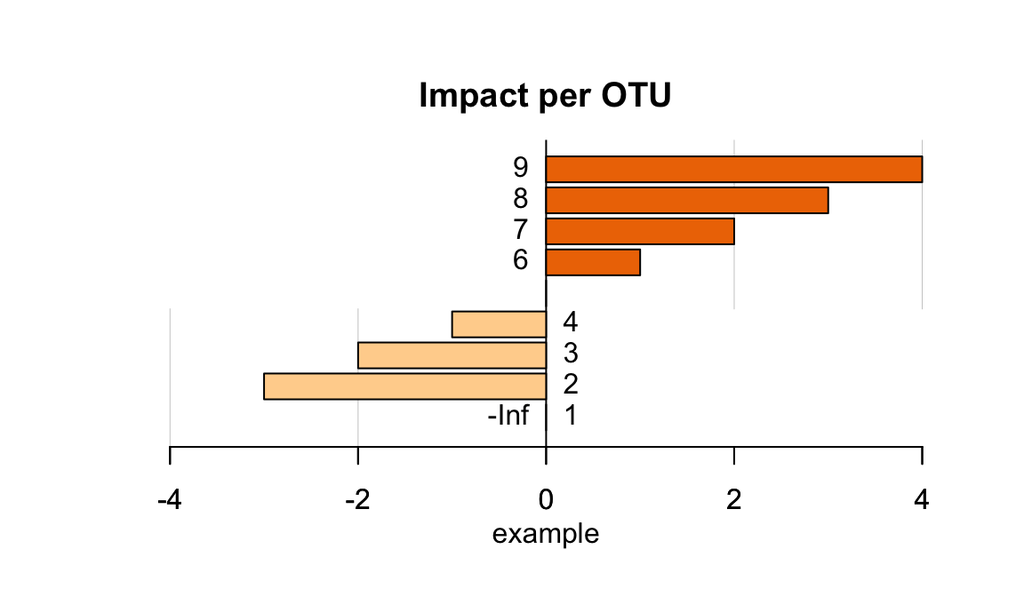

```
## [1] TRUE
```

```r
source("~/Documents/Repos/BioLockJ/resources/R/BuildEffectSizePlots.R")

toPlot = data.frame(example=c(-Inf,-3:4))
drawPlot(toPlot=toPlot, barSizeColumn="example")
```

This method sizes the plot so that the width of a bar is equal to one line of text, even that creates empty space at the bottom of the plot region.

```r
toPlot = data.frame(example=c(-Inf,-3:4))
drawPlot(toPlot=toPlot, barSizeColumn="example", comments="The plot is sized so that on 1 bar = 1 line of text.")
```

```
## [1] TRUE
```

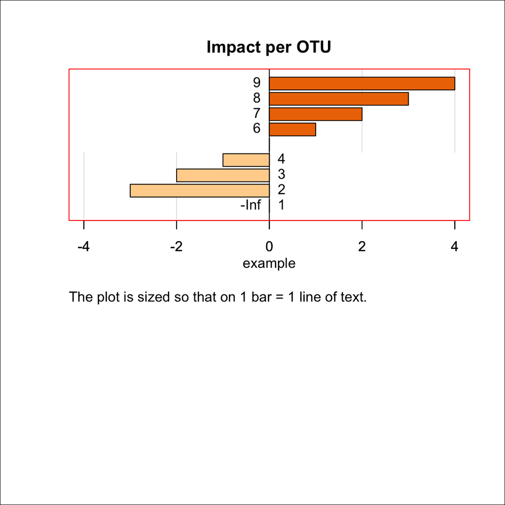

```r
box("figure"); box("plot", col="red")
```

If there is not enough space, then bars get squished, labels may overlap, and comments may be left off.

```r
toPlot = data.frame(example=c(-Inf,-15:34))
drawPlot(toPlot=toPlot, barSizeColumn="example", comments="The plot is sized so that on 1 bar = 1 line of text.")
```

```
## [1] "Not enough space in plot for 51 bars with 0.2 for each bar. Bar widths will be set to fit the space."
```

```
## [1] TRUE
```

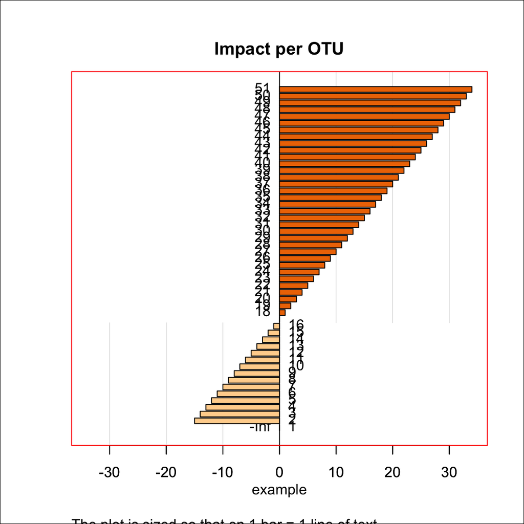

```r
box("figure"); box("plot", col="red")
```

This re-sizing can be ignored by setting `fixedBarHeightInches` to NULL. It can also set explicitly by setting `fixedBarHeightInches` to a positive value, ideally the character heigh can be set as needed to fit the bars.

Labels and colors can be set per-bar by adding an “OTU” column (or row.names can be used), and a “color” column, respectively.

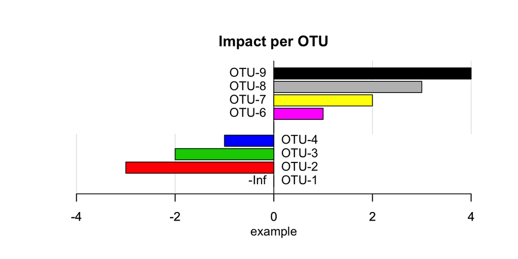

```
## [1] TRUE
```

```r
toPlot = data.frame(row.names=paste0("OTU-", 1:9),
                                        example=c(-Inf,-3:4),
                                        color=1:9)
drawPlot(toPlot=toPlot, barSizeColumn="example")
```

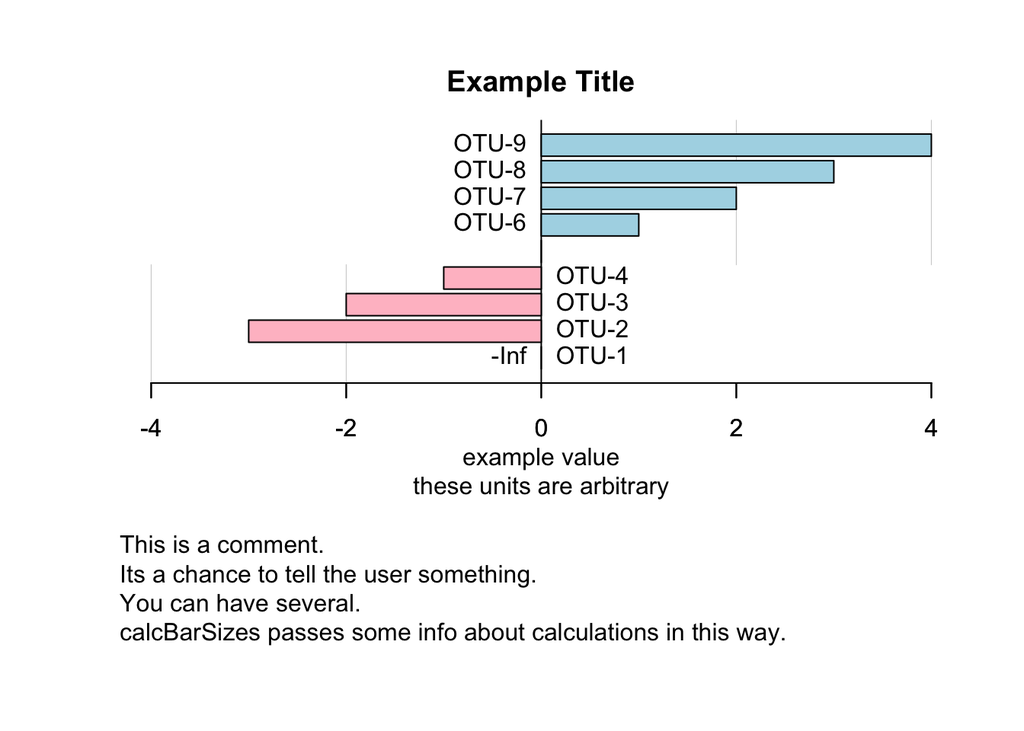

```
## [1] TRUE
```

```r
toPlot = data.frame(row.names=paste0("OTU-", 1:9),
                                        example=c(-Inf,-3:4))
drawPlot(toPlot=toPlot, barSizeColumn="example",
                 numGroupColor="lightblue", denGroupColor="pink",
                 xAxisLab="example value", title="Example Title", xAxisLab2="these units are arbitrary",
                 comments = c("This is a comment.", "Its a chance to tell the user something.",
                                         "You can have several.", "calcBarSizes passes some info about calculations in this way."))
```

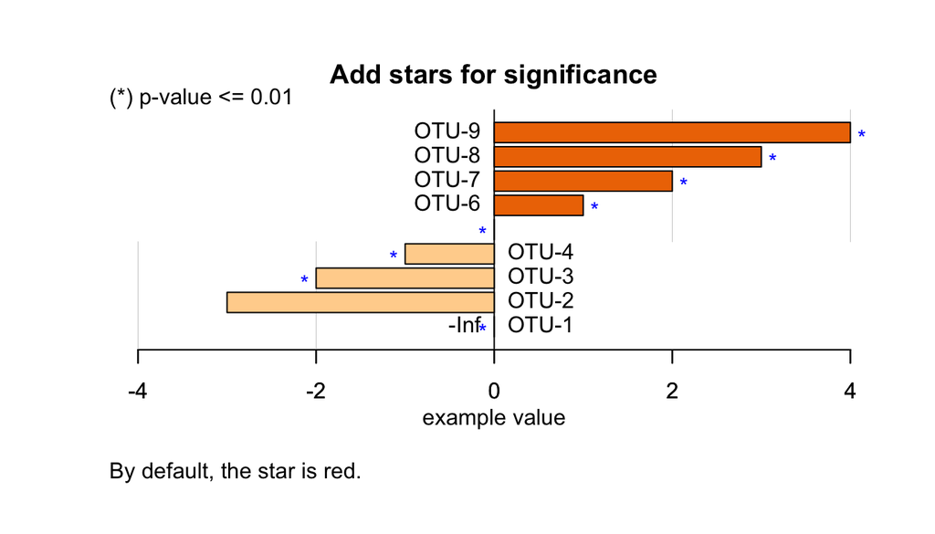

```
## [1] TRUE
```

```r
toPlot = data.frame(row.names=paste0("OTU-", 1:9),
                                        example=c(-Inf,-3:4),
                                        pvalue=rnorm(9,.01))
drawPlot(toPlot=toPlot, barSizeColumn="example",
                 xAxisLab="example value", title="Add stars for significance",
                 comments = c("By default, the star is red."),
                 pvalStar=0.01, starColor="blue")
```

By default, `centerAt0` is set to true, and this gives the maximum possible space for lables. But the plot does not have to be horizontally centered at 0.

```r
par(mfrow=c(1,3))
toPlot = data.frame(positives=rnorm(9, 10),
                                        negatives=rnorm(9, -10),
                                        offCenter=c(-2:6))
drawPlot(toPlot=toPlot, barSizeColumn="positives", centerAt0 = FALSE)
```

```
## [1] TRUE
```

```r
drawPlot(toPlot=toPlot, barSizeColumn="negatives", centerAt0 = FALSE)
```

```
## [1] TRUE
```

```
## [1] TRUE
```

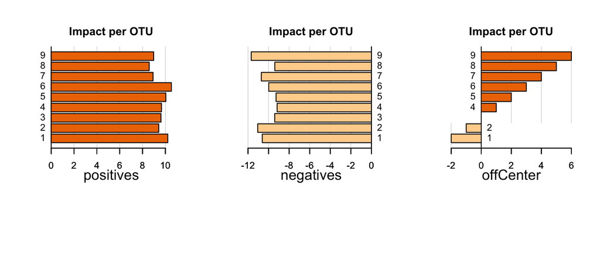

```r
drawPlot(toPlot=toPlot, barSizeColumn="offCenter", centerAt0 = FALSE)
```

To create an interactive R session similar to the one produced by a BiolockJ pipeline, run the following:

```r
testModuleDir = <path to BuildEffectSizePlots module in a completed BiolockJ pipeline>
setwd(testModuleDir)
getModuleScript <- function(){
    return(paste0(testModuleDir, "/script/BuildEffectSizePlots.R"))
}
source("script/BioLockJ_Lib.R")
source("script/BuildEffectSizePlots.R")
doDebug<-function(){return(TRUE)} # for interactive use force this to return true, regardless of the current config setting.
```